# InVivoStat Single Measure Parametric Analysis

## Response

The Resp 1 response is currently being analysed by the Single Measures Parametric Analysis module.The response has been log10 transformed prior to analysis.

## Scatterplot of the observed data (on the log10 scale)

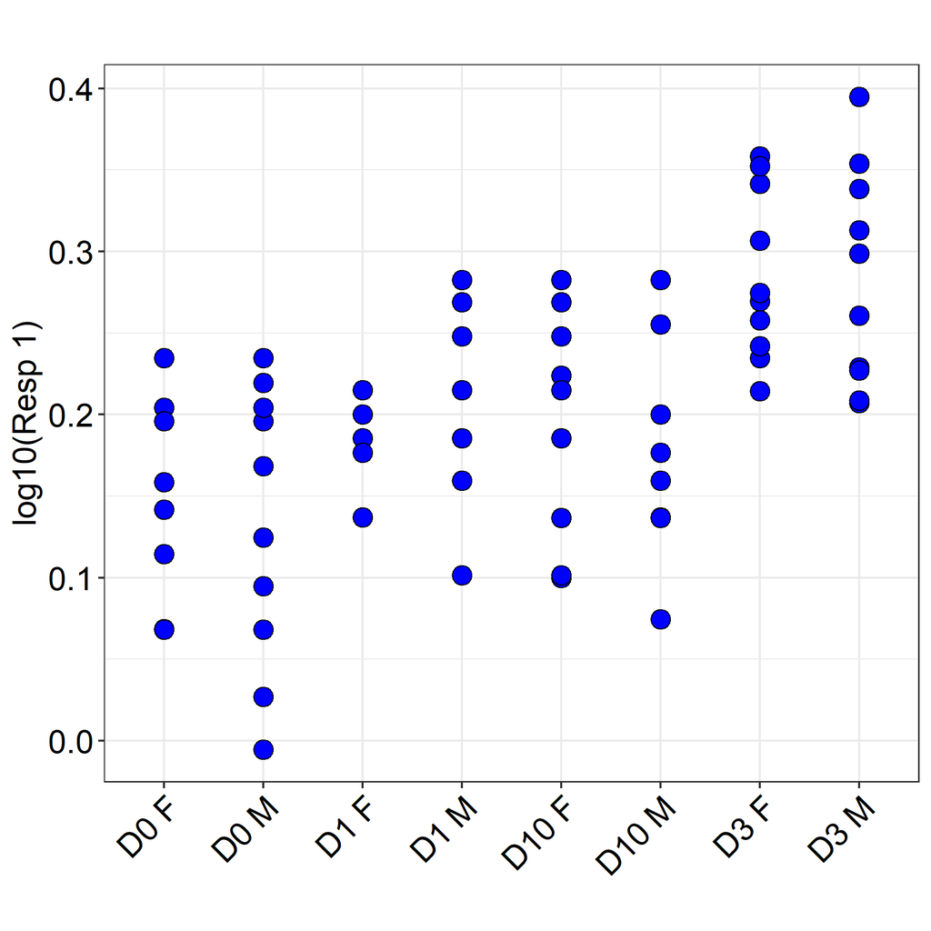

Tip: Use this plot to identify possible outliers.

## Analysis of variance (ANOVA) table

| Effect | Sums of squares | Degrees of freedom | Mean square | F-value | p-value |
| --- | --- | --- | --- | --- | --- |
| Treat1 | 0.208 | 3 | 0.069 | 16.54 | < 0.0001 |
| Treat2 | 0.000 | 1 | 0.000 | 0.02 | 0.8772 |
| Treat1 * Treat2 | 0.010 | 3 | 0.003 | 0.80 | 0.5002 |
| Residual | 0.293 | 70 | 0.004 |  |  |

Comment: ANOVA table calculated using a Type III model fit, see Armitage et al. (2001).

Conclusion: At the 5% level, there is a statistically significant overall difference between the levels of Treat1.

Tip: While it is a good idea to consider the overall tests in the ANOVA table, we should not rely on them when deciding whether or not to make pairwise comparisons.

## Model coefficients

|  | Estimate | Std. Error | t-value | p-value |
| --- | --- | --- | --- | --- |
| (Intercept) | 0.2010 | 0.0073 | 27.36 | < 0.0001 |
| Treat11 | -0.0603 | 0.0131 | -4.60 | < 0.0001 |
| Treat12 | -0.0100 | 0.0126 | -0.79 | 0.4310 |
| Treat13 | -0.0129 | 0.0126 | -1.02 | 0.3096 |
| Treat21 | 0.0011 | 0.0073 | 0.16 | 0.8772 |
| Treat11:Treat21 | 0.0064 | 0.0131 | 0.49 | 0.6255 |
| Treat12:Treat21 | -0.0181 | 0.0126 | -1.43 | 0.1564 |
| Treat13:Treat21 | 0.0117 | 0.0126 | 0.93 | 0.3546 |

## Diagnostic plots

### Residuals vs. predicted plot

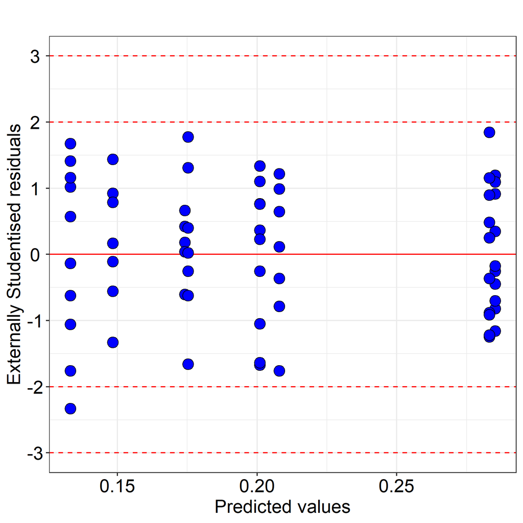

Tip: On this plot look to see if the spread of the points increases as the predicted values increase. If so the response may need transforming.

Tip: Any observation with a residual less than -3 or greater than 3 (SD) should be investigated as a possible outlier.

### Normal probability plot

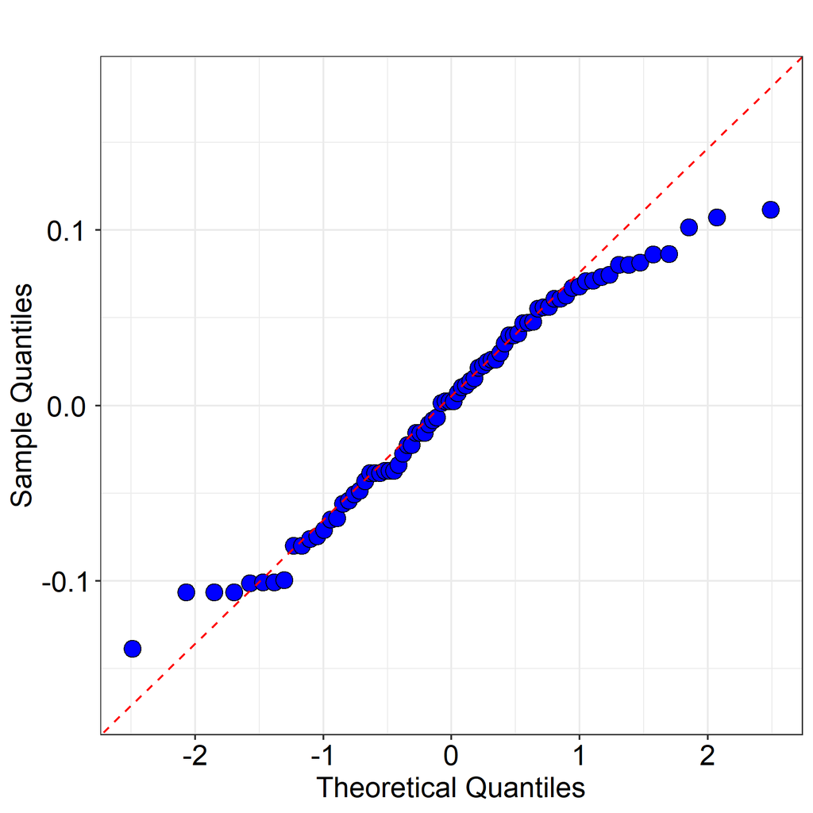

Tip: Check that the points lie along the dotted line. If not then the data may be non-normally distributed.

## Table of the least square (predicted) means with 95% confidence intervals

| Mean ID | Treat1 | Mean | Lower 95% CI | Upper 95% CI |
| --- | --- | --- | --- | --- |
| 1 | D0 | 0.141 | 0.110 | 0.171 |
| 2 | D1 | 0.191 | 0.162 | 0.220 |
| 3 | D10 | 0.188 | 0.159 | 0.217 |
| 4 | D3 | 0.284 | 0.255 | 0.313 |

## Plot of the least square (predicted) means with 95% confidence intervals

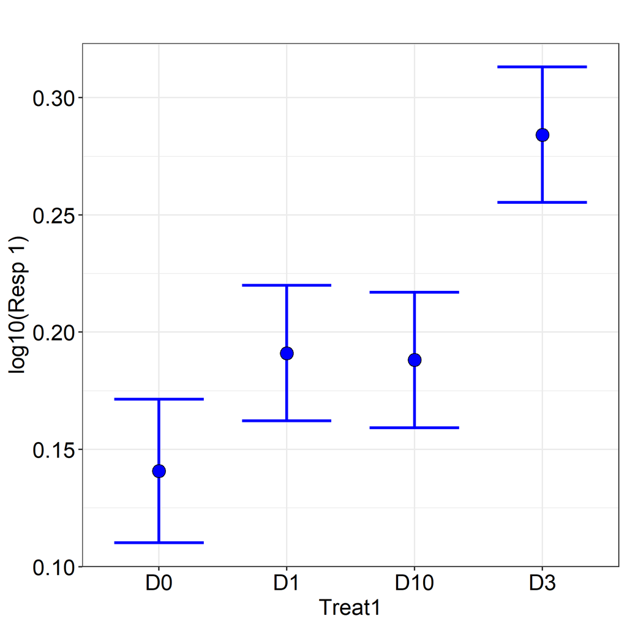

## Table of the back-transformed geometric means with 95% confidence intervals

As the response was log transformed prior to analysis the least square (predicted) means are presented on the log scale. These results can be back transformed onto the original scale. These are known as the back-transformed geometric means.

| Mean ID | Treat1 | Geometric mean | Lower 95% CI | Upper 95% CI |
| --- | --- | --- | --- | --- |
| 1 | D0 | 1.383 | 1.289 | 1.484 |
| 2 | D1 | 1.553 | 1.453 | 1.659 |
| 3 | D10 | 1.542 | 1.443 | 1.648 |
| 4 | D3 | 1.924 | 1.800 | 2.056 |

## Plot of the back-transformed geometric means with 95% confidence intervals

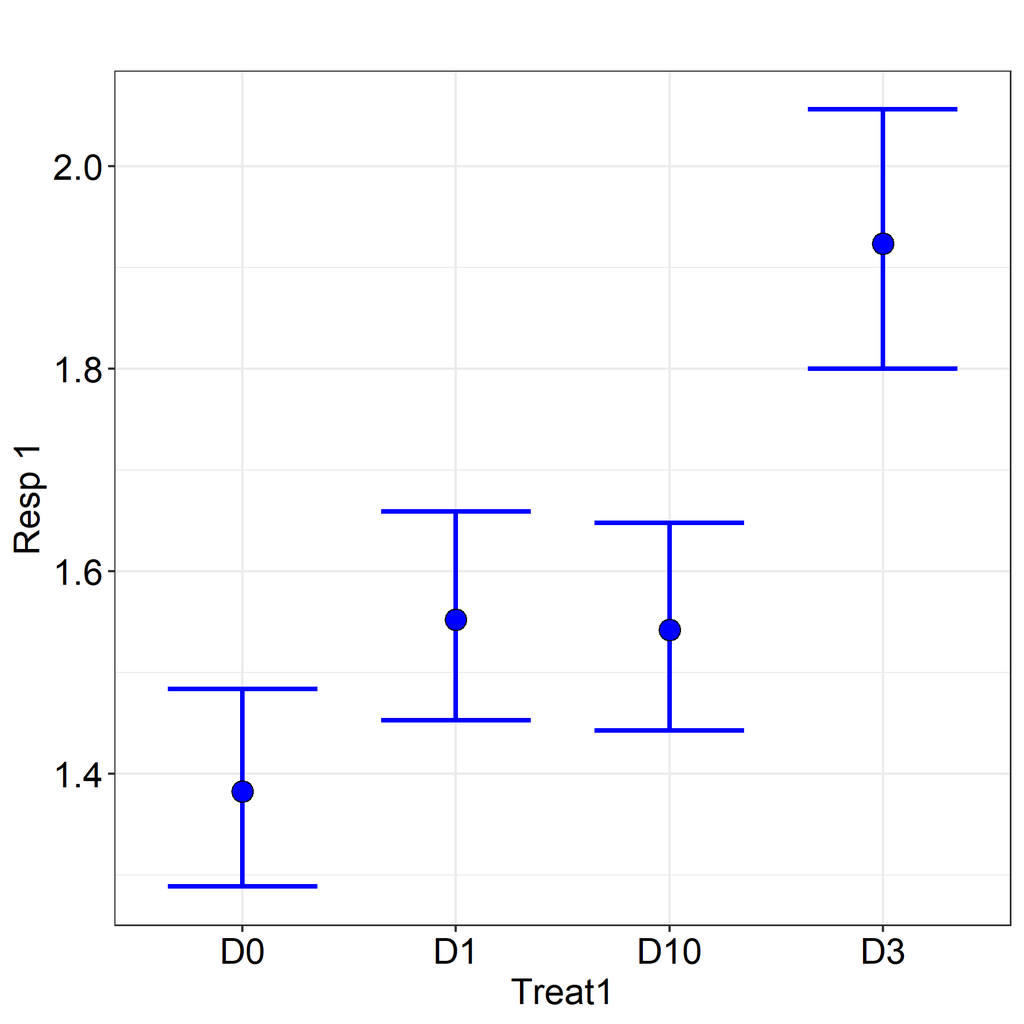

## All pairwise comparisons using Hommel's procedure

| Comparison | Difference | Lower 95% CI | Upper 95% CI | Std error | p-value |
| --- | --- | --- | --- | --- | --- |
| D0 - D1 | -0.050 | -0.092 | -0.008 | 0.021 | 0.0418 |
| D0 - D10 | -0.047 | -0.089 | -0.005 | 0.021 | 0.0558 |
| D0 - D3 | -0.143 | -0.186 | -0.101 | 0.021 | < 0.0001 |
| D1 - D10 | 0.003 | -0.038 | 0.044 | 0.020 | 0.8872 |
| D1 - D3 | -0.093 | -0.134 | -0.052 | 0.020 | < 0.0001 |
| D10 - D3 | -0.096 | -0.137 | -0.055 | 0.020 | < 0.0001 |

## All pairwise comparisons as back-transformed ratios using Hommel's procedure

As the response was log transformed prior to analysis the differences between the least square (predicted) means are presented on the log scale. These results can be back-transformed, where differences on the log scale become ratios when back-transformed.

| Comparison | Ratio | Lower 95% CI | Upper 95% CI | p-value |
| --- | --- | --- | --- | --- |
| D0 / D1 | 0.891 | 0.808 | 0.981 | 0.0418 |
| D0 / D10 | 0.897 | 0.814 | 0.988 | 0.0558 |
| D0 / D3 | 0.719 | 0.652 | 0.792 | < 0.0001 |
| D1 / D10 | 1.007 | 0.916 | 1.106 | 0.8872 |
| D1 / D3 | 0.807 | 0.735 | 0.887 | < 0.0001 |
| D10 / D3 | 0.802 | 0.730 | 0.881 | < 0.0001 |

Conclusion: The following pairwise comparisons are statistically significant at the 5% level: (1) D0 / D1, (2) D0 / D3, (3) D1 / D3, (4) D10 / D3.

Warning: It is not advisable to draw statistical inferences about a factor/interaction in the presence of a significant higher-order interaction involving that factor/interaction.

Warning: This procedure makes an adjustment assuming you want to make all pairwise comparisons. If this is not the case then these tests may be unduly conservative. You may wish to use planned comparisons (using unadjusted p-values) instead, see Snedecor and Cochran (1989), or make a manual adjustment to the unadjusted p-values using the InVivoStat P-value Adjustment module.

Note: The confidence intervals quoted are not adjusted for multiplicity.

## All to one comparisons using Hommel's procedure

| Comparison | Difference | Lower 95% CI | Upper 95% CI | Std error | p-value |
| --- | --- | --- | --- | --- | --- |
| D1 - D0 | 0.050 | 0.008 | 0.092 | 0.021 | 0.0279 |
| D10 - D0 | 0.047 | 0.005 | 0.089 | 0.021 | 0.0279 |
| D3 - D0 | 0.143 | 0.101 | 0.186 | 0.021 | < 0.0001 |

## Plot of the comparisons between the predicted means with 95% confidence intervals

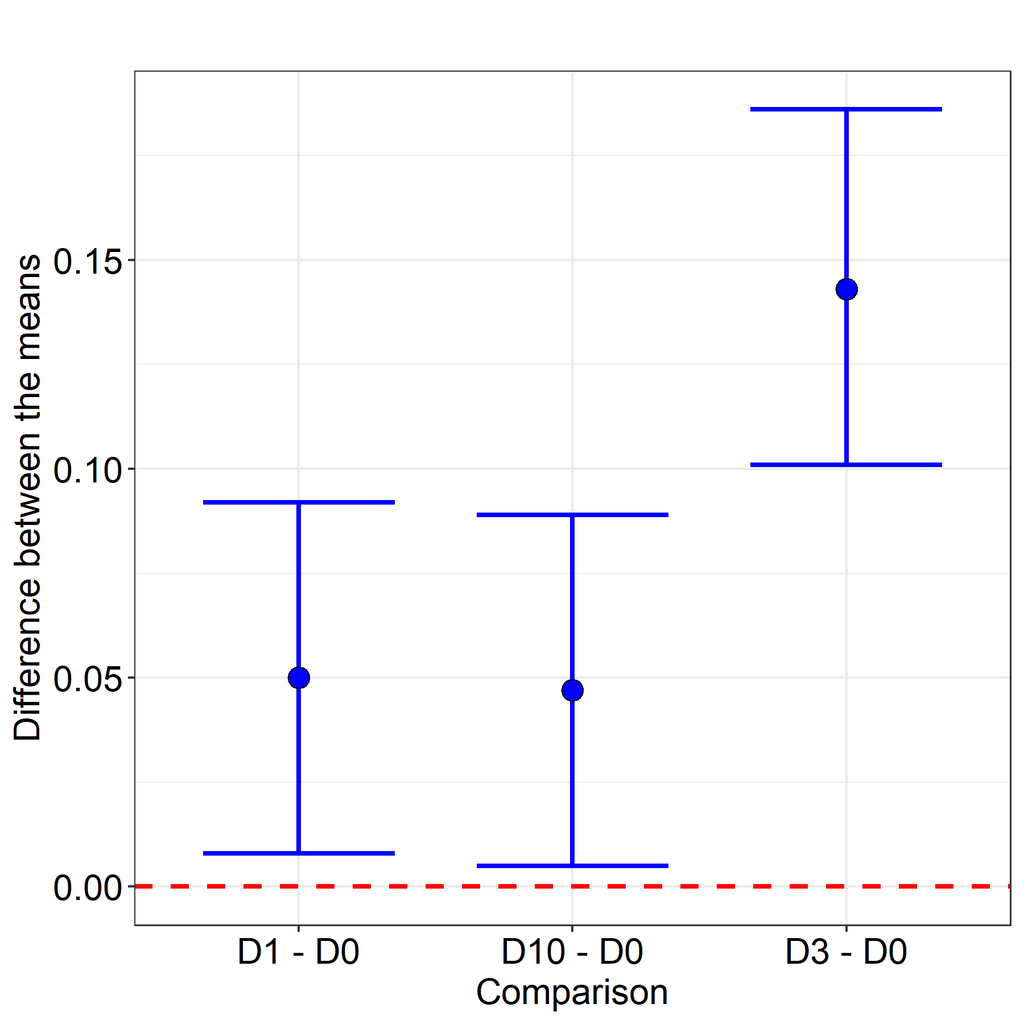

## All to one comparisons as back-transformed ratios using Hommel's procedure

As the response was log transformed prior to analysis the differences between the least square (predicted) means are presented on the log scale. These results can be back-transformed, where differences on the log scale become ratios when back-transformed.

| Comparison | Ratio | Lower 95% CI | Upper 95% CI | p-value |
| --- | --- | --- | --- | --- |
| D1 / D0 | 1.123 | 1.019 | 1.237 | 0.0279 |
| D10 / D0 | 1.115 | 1.012 | 1.229 | 0.0279 |
| D3 / D0 | 1.391 | 1.263 | 1.533 | < 0.0001 |

## Plot of the comparisons between the back-transformed geometric means with 95% confidence intervals

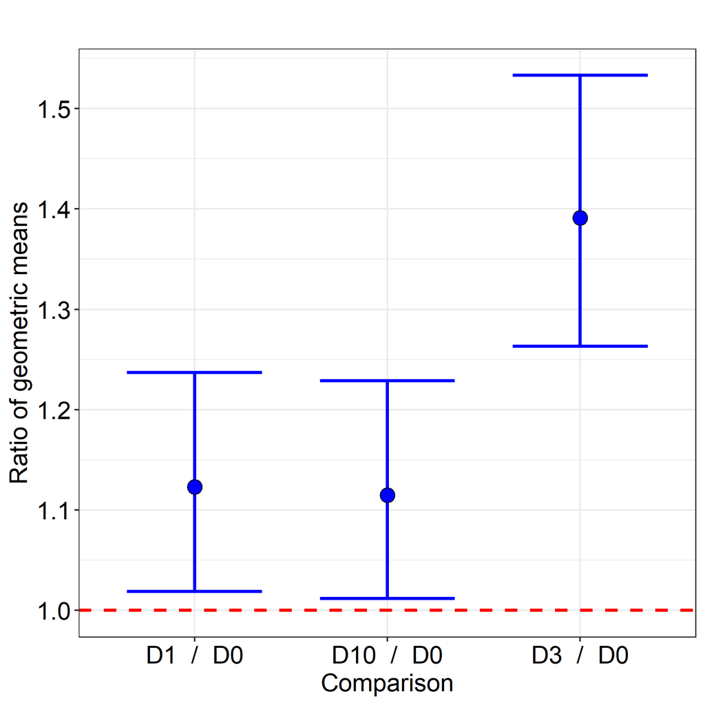

Conclusion: The following pairwise comparisons are statistically significant at the 5% level: (1) D1 / D0, (2) D10 / D0, (3) D3 / D0.

Warning: It is not advisable to draw statistical inferences about a factor/interaction in the presence of a significant higher-order interaction involving that factor/interaction. In the above table certain higher order interactions are assumed to be not significant, see log for more details.

Note: The confidence intervals quoted are not adjusted for multiplicity.

## Analysis description

The data were analysed using a 2-way ANOVA approach, with Treat1 and Treat2 as the treatment factors. This was followed by comparisons of the predicted means of the Treat1 factor back to the control group mean using Hommel's procedure, Hommel (1988). This was followed by all pairwise comparisons between the predicted means of the Treat1 factor using Hommel's procedure, Hommel (1988). The response was log10 transformed prior to analysis to stabilise the variance.

For more information on the theoretical approaches that are implemented within this module, see Bate and Clark (2014).

## References

When referring to InVivoStat, please cite 'InVivoStat, version 5.2.0'.

Bate, S.T. and Clark, R.A. (2014). The Design and Statistical Analysis of Animal Experiments. Cambridge University Press.

Armitage, P., Matthews, J.N.S. and Berry, G. (2001). Statistical Methods in Medical Research. 4th edition; John Wiley & Sons. New York.

Hommel, G. (1988). A stagewise rejective multiple test procedure based on a modified Bonferroni test. Biometrika, 75, 383-386.

Snedecor, G.W. and Cochran, W.G. (1989). Statistical Methods. 8th edition; Iowa State University Press, Iowa, USA.